# Delineating a watershed

## 0. Preparing the installation

Be sure you have followed the installation guide and have a working installation of `watershed`, `rgrass7`, and Grass GIS 7.4 or 7.6 (other version may work, but are untested).

## 0.5. Preparing the DEM

Many workflows advise either using a “burned-in” DEM or a “filled” DEM to avoid topological problems. The tools used by `watershed` should in theory not require either of those steps, so in general it is recommended you skip this step unless you encounter problems later on. Burning in a DEM is not yet supported, so if this step is required it is best to use another tool and then bring the already burned DEM into R. Filling the DEM is supported however; see `?fill_dem`.

## 1. Delineating the stream

The pared-down workflow offered by `watershed` provides a relatively quick way to go from a dem to a stream map. We will make a first-draft map using the `kamp_dem` dataset provided by this package, for the Kamp river in Austria. The DEM is a `raster`, so we load this package as well.

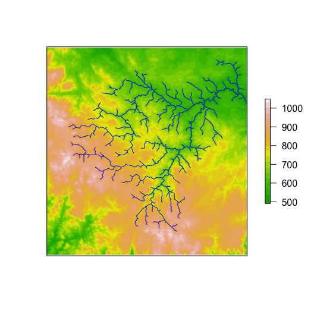

```r
library(watershed)
library(raster)
library(sf)
data(kamp_dem)
kamp = delineate(kamp_dem, outlet = NA)
kv = vectorise_stream(kamp[["stream"]])
## WARNING: Memory leak: 4 points are still in use
plot(kamp_dem, col=terrain.colors(20), axes = FALSE)
plot(st_geometry(kv), col='blue', add = TRUE)
```

## 2. Generating topologies

Many later features require a topology; this simply a square matrix `T`, with one row/column for each pixel or reach in the river network. `T[i,j] == 1` indicates that pixel/reach `i` is directly upstream of pixel/reach `j` (in other words, `j` gets water from `i` without that water flowing through any other intermediate pixels/reaches).

Generating the topology can take some time for large and/or complex river networks, so it is best to do it once you have a reasonable first pass.

```r
library(Matrix)
kamp_Tp = pixel_topology(kamp)
```

```
## Warning in .check_topology(res, warn = TRUE): Invalid topology; 1 nodes are
## downstream of more than two nodes.
```

```r
kamp_Tr = reach_topology(kamp, kamp_Tp)
```

Note the warning, indicating that there is a confluence where more than 2 streams flow into the same pixel. This is not a serious problem, so we will ignore it for now.

## 3. Producing smaller reaches

The default output from `delineate` is to assign each pixel to a reach, where a reach is a stretch of river between confluences. For many applications, it is useful to split these into smaller sections. `watershed` includes a function to split reaches into fixed (approximately) equal-length sections.

- Note that resizing the reaches invalidates the old topologies, and a new ones must be made.
- Alternatively, we could define the reach lengths directly in `delineate` by setting the `reach_len` parameter.
- Setting `trim=TRUE` will remove small (by default, length < target_length/2) headwater reaches from the network

```r
new_reaches = resize_reaches(kamp$stream, kamp_Tp, 2000, trim=TRUE)
new_v = vectorise_stream(new_reaches)
## WARNING: Memory leak: 4 points are still in use
new_Tp = pixel_topology(drainage = kamp$drainage, stream = new_reaches)
new_Tr = reach_topology(Tp = new_Tp, stream = new_reaches)

## how many reaches, and what range of lengths?
c(nrow(kamp_Tr), nrow(new_Tr))
```

```
## [1] 318 292
```

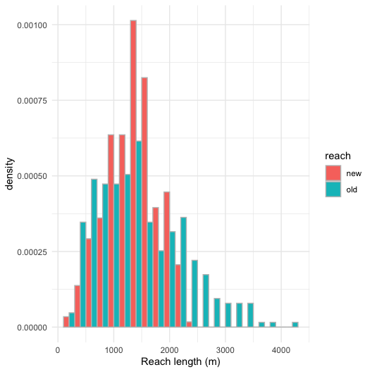

```r
library(ggplot2)
pl = ggplot(data.frame(len = c(kamp_Tr@x, new_Tr@x),
                  reach = c(rep("old", length(kamp_Tr@x)), rep("new", length(new_Tr@x)))), aes(x=len, fill=reach))
pl + geom_histogram(aes(y=..density..), position="dodge", binwidth = 200, colour="gray") + theme_minimal() + xlab("Reach length (m)")
```

```r
## update the raster stack to use the new streams
kamp[["stream"]] = new_reaches
kv = new_v
kamp_Tp = new_Tp
kamp_Tr = new_Tr
rm(list=c("new_reaches", "new_v", "new_Tp", "new_Tr"))
```

## 4. Computing catchment area

`watershed` can compute catchment area for you at any set of points in the watershed; this will yield the total area draining into a given point. Note that this can take a very long time for large areas. Here, we will compute the catchment area per reach.

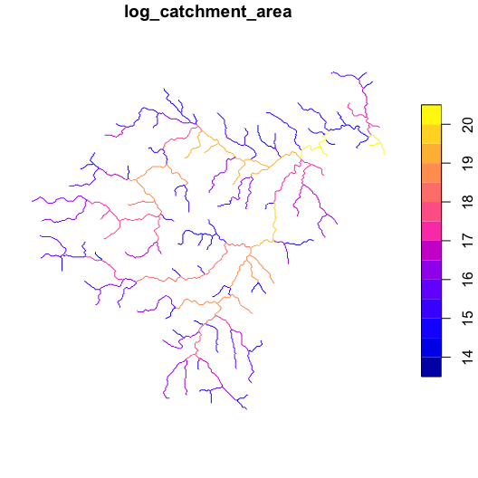

```r
CA = catchment(kamp, type = 'reach', Tp = kamp_Tp)
rids = unique(kamp$stream)
## not all reaches survive the transition to vector, and the orders are not the same, so we match by rid
## We also convert to log scale to make the map more readable
kv$catch_area = CA[kv$reach_id]
kv$log_catchment_area = log(kv$catch_area)
plot(kv['log_catchment_area'])
```

## Discharge and hydraulic geometry

We load the dataset `kamp_q` for observations of discharge. We first need to make sure the points are exactly on the stream, then compute the catchment area for each point. We set units using the `units` package to make sure unit conversions in the scaling equations are handled correctly. Finally, we can then use the reach-level catchment areas to compute discharge and geometry for every reach in the watershed.

```r
library(units)
data(kamp_q)
kamp_q = sf::st_snap(kamp_q, kv, tolerance = 200)
kamp_q$catch_area = catchment(kamp, type = "points", y = st_coordinates(kamp_q))
h <- hydraulic_geometry(set_units(kamp_q$catch_area, "m^2"), kamp_q$discharge, set_units(kv$catch_area, "m^2"))
head(h)
```

```
##               CA                  Q                 v               z
## 1  6580000 [m^2] 0.03461719 [m^3/s] 0.005168466 [m/s] 0.009709420 [m]
## 2  2400000 [m^2] 0.01679714 [m^3/s] 0.004205867 [m/s] 0.007849837 [m]
## 3 17060000 [m^2] 0.06854139 [m^3/s] 0.006279283 [m/s] 0.011868932 [m]
## 4  2290000 [m^2] 0.01624149 [m^3/s] 0.004165737 [m/s] 0.007772585 [m]
## 5 21270000 [m^2] 0.08028479 [m^3/s] 0.006568768 [m/s] 0.012433794 [m]
## 6 21270000 [m^2] 0.08028479 [m^3/s] 0.006568768 [m/s] 0.012433794 [m]
##                w
## 1 0.05957440 [m]
## 2 0.04387466 [m]
## 3 0.07953298 [m]
## 4 0.04325476 [m]
## 5 0.08503526 [m]
## 6 0.08503526 [m]
```

## My network doesn’t match aerial photos!